# Social Network Analysis of Global Live Animal Movements (FAOSTAT, 2005-2021)

Ascension

2026-08-23

# 1 Purpose and scope

This document builds a **directed, weighted country-to-country network of live animal movements** from the FAOSTAT *Detailed trade matrix* (domain code `TM`) extracts stored in `Data/`.

The workflow is:

1. Load and harmonise every yearly CSV (Section @ref(load)).
2. Validate that variables match across files and that no record is duplicated (Section @ref(validate)).
3. Produce a descriptive-statistics workbook (Section @ref(descriptives)).
4. Build three networks - **in-degree**, **out-degree** and **overall (total) degree** - from all years and all species combined (Section @ref(networks)).
5. Draw each network on a real world map (Section @ref(maps)).
6. Repeat the three networks **per species** (Section @ref(species)).

Everything the script writes goes to `Output/` inside this project folder.

```r
pkgs <- c("dplyr", "tidyr", "readr", "stringr", "purrr", "tibble",
          "igraph", "ggplot2", "ggrepel", "scales", "openxlsx",
          "sf", "maps", "rnaturalearthdata")

invisible(lapply(pkgs, function(p) {
  if (!requireNamespace(p, quietly = TRUE))
    stop("Package '", p, "' is required. Install it with install.packages('", p, "').")
  suppressPackageStartupMessages(library(p, character.only = TRUE))
}))

set.seed(20260823)

# ---- project paths -----------------------------------------------------------
data_dir   <- "Data"
out_dir    <- "Output"
fig_dir    <- file.path(out_dir, "figures")
tab_dir    <- file.path(out_dir, "tables")
net_dir    <- file.path(out_dir, "networks")
spp_dir    <- file.path(fig_dir, "species")
for (d in c(out_dir, fig_dir, tab_dir, net_dir, spp_dir))
  dir.create(d, showWarnings = FALSE, recursive = TRUE)
```

# 2 Load and harmonise the yearly files

Each CSV is a FAOSTAT bulk extract with 16 columns. **The file names do not correspond to the year of the records they contain** (for example `2005Combined.csv` holds the 2009 records), so the year is always taken from the `Year` column, never from the file name.

```r
files <- list.files(data_dir, pattern = "\\.csv$", full.names = TRUE)
stopifnot(length(files) > 0)

# Every column is read as text first. FAOSTAT writes some M49 codes with leading zeros
# ("004"), which makes readr guess `character` in some files and `double` in others; reading
# as text and coercing explicitly guarantees the variables match across all files.
read_fao <- function(path) {
  readr::read_csv(path, show_col_types = FALSE, progress = FALSE,
                  col_types = readr::cols(.default = readr::col_character()),
                  locale = readr::locale(encoding = "UTF-8")) %>%
    dplyr::mutate(source_file = basename(path))
}

raw_list <- lapply(files, read_fao)
names(raw_list) <- basename(files)

# tidy the column names once, consistently, for every file
clean_names <- function(x) {
  x %>%
    stringr::str_replace_all("", "") %>%
    stringr::str_trim()
}
raw_list <- lapply(raw_list, function(d) { names(d) <- clean_names(names(d)); d })

# name-to-year map (documents the file/year mismatch)
file_year_map <- purrr::imap_dfr(raw_list, ~ tibble::tibble(
  source_file   = .y,
  n_rows        = nrow(.x),
  years_in_file = paste(sort(unique(.x$Year)), collapse = ", ")
))
file_year_map
```

```
## # A tibble: 16 x 3
##    source_file      n_rows years_in_file
##    <chr>             <int> <chr>
##  1 2005Combined.csv   6873 2009
##  2 2006Combined.csv   8231 2013
##  3 2007Combined.csv   6889 2006
##  4 2008Combined.csv   7081 2010
##  5 2009Combined.csv   7301 2007
##  6 2011Combined.csv   7059 2008
##  7 2012Combined.csv   7245 2005
##  8 2013Combined.csv   7123 2011
##  9 2014Combined.csv   8024 2012
## 10 2015Combined.csv  17688 2014
## 11 2016Combined.csv  17944 2020
## 12 2017Combined.csv  19218 2018
## 13 2018Combined.csv  18600 2021
## 14 2019Combined.csv  18982 2017
## 15 2020Combined.csv  17586 2015
## 16 2021Combined.csv  18070 2016
```

## 2.1 Do the variables match across datasets?

```r
col_sets <- lapply(raw_list, names)
ref_cols <- col_sets[[1]]

col_check <- tibble::tibble(
  source_file      = names(col_sets),
  n_columns        = lengths(col_sets),
  identical_names  = vapply(col_sets, function(x) identical(x, ref_cols), logical(1)),
  same_order       = vapply(col_sets, function(x) identical(x, ref_cols), logical(1)),
  missing_vs_ref   = vapply(col_sets, function(x) paste(setdiff(ref_cols, x), collapse = "; "), character(1)),
  extra_vs_ref     = vapply(col_sets, function(x) paste(setdiff(x, ref_cols), collapse = "; "), character(1))
)
col_check
```

```
## # A tibble: 16 x 6
##    source_file  n_columns identical_names same_order missing_vs_ref extra_vs_ref
##    <chr>            <int> <lgl>           <lgl>      <chr>          <chr>
##  1 2005Combine~        17 TRUE            TRUE       ""             ""
##  2 2006Combine~        17 TRUE            TRUE       ""             ""
##  3 2007Combine~        17 TRUE            TRUE       ""             ""
##  4 2008Combine~        17 TRUE            TRUE       ""             ""
##  5 2009Combine~        17 TRUE            TRUE       ""             ""
##  6 2011Combine~        17 TRUE            TRUE       ""             ""
##  7 2012Combine~        17 TRUE            TRUE       ""             ""
##  8 2013Combine~        17 TRUE            TRUE       ""             ""
##  9 2014Combine~        17 TRUE            TRUE       ""             ""
## 10 2015Combine~        17 TRUE            TRUE       ""             ""
## 11 2016Combine~        17 TRUE            TRUE       ""             ""
## 12 2017Combine~        17 TRUE            TRUE       ""             ""
## 13 2018Combine~        17 TRUE            TRUE       ""             ""
## 14 2019Combine~        17 TRUE            TRUE       ""             ""
## 15 2020Combine~        17 TRUE            TRUE       ""             ""
## 16 2021Combine~        17 TRUE            TRUE       ""             ""
```

```r
# column classes must also agree, otherwise bind_rows would silently coerce
class_check <- purrr::imap_dfr(raw_list, function(d, nm) {
  tibble::tibble(source_file = nm, variable = names(d),
                 class = vapply(d, function(x) class(x)[1], character(1)))
}) %>%
  dplyr::group_by(variable) %>%
  dplyr::summarise(distinct_classes = paste(sort(unique(class)), collapse = " | "),
                   .groups = "drop")
class_check
```

```
## # A tibble: 17 x 2
##    variable                    distinct_classes
##    <chr>                       <chr>
##  1 Domain                      character
##  2 Domain Code                 character
##  3 Element                     character
##  4 Element Code                character
##  5 Flag                        character
##  6 Flag Description            character
##  7 Item                        character
##  8 Item Code (CPC)             character
##  9 Partner Countries           character
## 10 Partner Country Code (M49)  character
## 11 Reporter Countries          character
## 12 Reporter Country Code (M49) character
## 13 Unit                        character
## 14 Value                       character
## 15 Year                        character
## 16 Year Code                   character
## 17 source_file                 character
```

```r
fao_raw <- dplyr::bind_rows(raw_list) %>%
  dplyr::rename(
    domain_code    = `Domain Code`,
    domain         = Domain,
    reporter_code  = `Reporter Country Code (M49)`,
    reporter       = `Reporter Countries`,
    partner_code   = `Partner Country Code (M49)`,
    partner        = `Partner Countries`,
    element_code   = `Element Code`,
    element        = Element,
    item_code      = `Item Code (CPC)`,
    item           = Item,
    year_code      = `Year Code`,
    year           = Year,
    unit           = Unit,
    value          = Value,
    flag           = Flag,
    flag_desc      = `Flag Description`
  ) %>%
  dplyr::mutate(
    dplyr::across(c(reporter, partner, element, item, unit, flag, flag_desc),
                  ~ stringr::str_squish(as.character(.x))),
    reporter_code = as.integer(reporter_code),
    partner_code  = as.integer(partner_code),
    year          = as.integer(year),
    value         = as.numeric(value)
  )

dim(fao_raw)
```

```
## [1] 193914     17
```

# 3 Data validation: matching variables and duplicated values

Three checks are run:

- **completeness** - missing values per variable;
- **duplication** - fully identical rows, and rows duplicated on the natural key `reporter x partner x element x item x year x unit`;
- **consistency of the country dictionary** - each M49 code must map to exactly one country name and vice versa (otherwise nodes would be split or merged by mistake).

```r
missing_tbl <- tibble::tibble(
  variable   = names(fao_raw),
  n_missing  = vapply(fao_raw, function(x) sum(is.na(x)), integer(1)),
  pct_missing = round(100 * vapply(fao_raw, function(x) mean(is.na(x)), numeric(1)), 3)
)
missing_tbl
```

```
## # A tibble: 17 x 3
##    variable      n_missing pct_missing
##    <chr>             <int>       <dbl>
##  1 domain_code           0           0
##  2 domain                0           0
##  3 reporter_code         0           0
##  4 reporter              0           0
##  5 partner_code          0           0
##  6 partner               0           0
##  7 element_code          0           0
##  8 element               0           0
##  9 item_code             0           0
## 10 item                  0           0
## 11 year_code             0           0
## 12 year                  0           0
## 13 unit                  0           0
## 14 value                 0           0
## 15 flag                  0           0
## 16 flag_desc             0           0
## 17 source_file           0           0
```

```r
nat_key <- c("reporter", "partner", "element", "item", "year", "unit")

dup_tbl <- tibble::tibble(
  check = c("Fully identical rows",
            "Rows duplicated on natural key (reporter, partner, element, item, year, unit)",
            "Rows duplicated on reporter/partner/element/item/year (across units)"),
  n_duplicates = c(
    sum(duplicated(fao_raw %>% dplyr::select(-source_file))),
    sum(duplicated(fao_raw[, nat_key])),
    sum(duplicated(fao_raw[, c("reporter", "partner", "element", "item", "year")]))
  )
)
dup_tbl
```

```
## # A tibble: 3 x 2
##   check                                                             n_duplicates
##   <chr>                                                                    <int>
## 1 Fully identical rows                                                         0
## 2 Rows duplicated on natural key (reporter, partner, element, item~            0
## 3 Rows duplicated on reporter/partner/element/item/year (across un~        64044
```

```r
# country dictionary
country_dict <- dplyr::bind_rows(
  fao_raw %>% dplyr::distinct(code = reporter_code, country = reporter),
  fao_raw %>% dplyr::distinct(code = partner_code,  country = partner)
) %>% dplyr::distinct()

dict_check <- tibble::tibble(
  n_entities          = nrow(country_dict),
  n_distinct_codes    = dplyr::n_distinct(country_dict$code),
  n_distinct_names    = dplyr::n_distinct(country_dict$country),
  one_to_one          = nrow(country_dict) == dplyr::n_distinct(country_dict$code) &&
                        nrow(country_dict) == dplyr::n_distinct(country_dict$country)
)
dict_check
```

```
## # A tibble: 1 x 4
##   n_entities n_distinct_codes n_distinct_names one_to_one
##        <int>            <int>            <int> <lgl>
## 1        200              200              200 TRUE
```

```r
# drop any row that is an exact duplicate (defensive; expected to remove 0 rows)
fao <- fao_raw %>% dplyr::distinct(dplyr::across(-source_file), .keep_all = TRUE)
cat("rows before:", nrow(fao_raw), " rows after de-duplication:", nrow(fao), "\n")
```

```
## rows before: 193914  rows after de-duplication: 193914
```

## 3.1 Building an unambiguous movement record

The FAOSTAT trade matrix is **mirrored**: one shipment can be reported twice, once as an *Export Quantity* by the exporter and once as an *Import Quantity* by the importer. Quantities are also published in three units (`An` = head, `1000 An` = thousand head, `t` = tonnes).

The rules applied here:

1. Keep only **head-count units** (`An`, `1000 An`); tonnes rows describe the same shipments in a different unit and would double-count. `1000 An` is converted to head.
2. Convert every record to a **direction**: for *Export Quantity* the flow is reporter -> partner; for *Import Quantity* the flow is partner -> reporter.
3. Collapse the mirror: a movement is uniquely identified by `origin x destination x species x year`. Where both sides reported it, the two records are merged into one and the larger reported head count is retained (`reported_by` records whether it came from the exporter, the importer, or both).
4. Self-loops (origin == destination) are removed.

```r
head_units <- c("An", "1000 An")

mov <- fao %>%
  dplyr::filter(unit %in% head_units) %>%
  dplyr::mutate(head = dplyr::if_else(unit == "1000 An", value * 1000, value)) %>%
  dplyr::mutate(
    origin_code = dplyr::if_else(element == "Export Quantity", reporter_code, partner_code),
    origin      = dplyr::if_else(element == "Export Quantity", reporter,      partner),
    dest_code   = dplyr::if_else(element == "Export Quantity", partner_code,  reporter_code),
    dest        = dplyr::if_else(element == "Export Quantity", partner,       reporter)
  ) %>%
  dplyr::filter(origin != dest)

movements <- mov %>%
  dplyr::group_by(origin_code, origin, dest_code, dest, item, year) %>%
  dplyr::summarise(
    head        = max(head, na.rm = TRUE),
    n_reports   = dplyr::n(),
    reported_by = dplyr::case_when(
      all(element == "Export Quantity") ~ "exporter only",
      all(element == "Import Quantity") ~ "importer only",
      TRUE                              ~ "both sides"
    ),
    .groups = "drop"
  )

cat("head-count rows:", nrow(mov),
    "| unique movements after mirror collapse:", nrow(movements), "\n")
```

```
## head-count rows: 129648 | unique movements after mirror collapse: 87729
```

```r
janitor_tbl <- movements %>% dplyr::count(reported_by, name = "n_movements")
janitor_tbl
```

```
## # A tibble: 3 x 2
##   reported_by   n_movements
##   <chr>               <int>
## 1 both sides          41919
## 2 exporter only       25593
## 3 importer only       20217
```

`movements` is the analysis table: **one row = one country-to-country movement of one species in one year**, with `head` = number of animals.

# 4 Descriptive statistics

The workbook `Output/tables/Descriptive_Statistics.xlsx` collects the summaries below.

```r
num_summary <- function(x) {
  x <- x[!is.na(x)]
  tibble::tibble(
    n = length(x), mean = mean(x), sd = stats::sd(x),
    min = min(x), q1 = stats::quantile(x, .25), median = stats::median(x),
    q3 = stats::quantile(x, .75), max = max(x), sum = sum(x)
  )
}
```

```r
variable_overview <- purrr::imap_dfr(fao %>% dplyr::select(-source_file), function(x, nm) {
  is_num <- is.numeric(x)
  tibble::tibble(
    variable    = nm,
    type        = class(x)[1],
    role        = dplyr::case_when(
      nm %in% c("value", "head")                    ~ "numeric measure",
      nm %in% c("year", "year_code")                ~ "time",
      nm %in% c("reporter", "partner", "reporter_code", "partner_code") ~ "node identifier",
      TRUE                                          ~ "categorical / metadata"),
    n_obs       = length(x),
    n_missing   = sum(is.na(x)),
    pct_missing = round(100 * mean(is.na(x)), 3),
    n_unique    = dplyr::n_distinct(x),
    mean        = if (is_num) round(mean(x, na.rm = TRUE), 3) else NA_real_,
    sd          = if (is_num) round(stats::sd(x, na.rm = TRUE), 3) else NA_real_,
    min         = if (is_num) min(x, na.rm = TRUE) else NA_real_,
    median      = if (is_num) stats::median(x, na.rm = TRUE) else NA_real_,
    max         = if (is_num) max(x, na.rm = TRUE) else NA_real_,
    example_levels = if (is_num) NA_character_
                     else paste(utils::head(sort(unique(x)), 6), collapse = "; ")
  )
})
variable_overview
```

```
## # A tibble: 16 x 13
##    variable     type  role   n_obs n_missing pct_missing n_unique   mean      sd
##    <chr>        <chr> <chr>  <int>     <int>       <dbl>    <int>  <dbl>   <dbl>
##  1 domain_code  char~ cate~ 193914         0           0        1    NA  NA
##  2 domain       char~ cate~ 193914         0           0        1    NA  NA
##  3 reporter_co~ inte~ node~ 193914         0           0      180   447.  2.55e2
##  4 reporter     char~ node~ 193914         0           0      180    NA  NA
##  5 partner_code inte~ node~ 193914         0           0      200   447.  2.57e2
##  6 partner      char~ node~ 193914         0           0      200    NA  NA
##  7 element_code char~ cate~ 193914         0           0        6    NA  NA
##  8 element      char~ cate~ 193914         0           0        2    NA  NA
##  9 item_code    char~ cate~ 193914         0           0       25    NA  NA
## 10 item         char~ cate~ 193914         0           0       15    NA  NA
## 11 year_code    char~ time  193914         0           0       16    NA  NA
## 12 year         inte~ time  193914         0           0       16  2015.  4.60e0
## 13 unit         char~ cate~ 193914         0           0        3    NA  NA
## 14 value        nume~ nume~ 193914         0           0    33998 11006.  2.25e5
## 15 flag         char~ cate~ 193914         0           0        4    NA  NA
## 16 flag_desc    char~ cate~ 193914         0           0        4    NA  NA
## # i 4 more variables: min <dbl>, median <dbl>, max <dbl>, example_levels <chr>
```

```r
cat_vars <- c("domain_code", "domain", "element", "item", "unit", "flag", "flag_desc")
categorical_freq <- purrr::map_dfr(cat_vars, function(v) {
  fao %>%
    dplyr::count(level = .data[[v]], name = "n") %>%
    dplyr::mutate(variable = v,
                  pct = round(100 * n / sum(n), 3)) %>%
    dplyr::arrange(dplyr::desc(n)) %>%
    dplyr::select(variable, level, n, pct)
})
categorical_freq %>% dplyr::group_by(variable) %>% dplyr::slice_head(n = 4) %>% dplyr::ungroup()
```

```
## # A tibble: 19 x 4
##    variable    level                                        n     pct
##    <chr>       <chr>                                    <int>   <dbl>
##  1 domain      Detailed trade matrix                   193914 100
##  2 domain_code TM                                      193914 100
##  3 element     Export Quantity                         100362  51.8
##  4 element     Import Quantity                          93552  48.2
##  5 flag        A                                       186653  96.3
##  6 flag        X                                         5870   3.03
##  7 flag        I                                         1347   0.695
##  8 flag        E                                           44   0.023
##  9 flag_desc   Official figure                         186653  96.3
## 10 flag_desc   Figure from international organizations   5870   3.03
## 11 flag_desc   Imputed value                             1347   0.695
## 12 flag_desc   Estimated value                             44   0.023
## 13 item        Horses                                   49107  25.3
## 14 item        Chickens                                 37247  19.2
## 15 item        Cattle                                   31498  16.2
## 16 item        Swine / pigs                             17718   9.14
## 17 unit        An                                       88775  45.8
## 18 unit        t                                        64044  33.0
## 19 unit        1000 An                                  41095  21.2
```

```r
value_by_element_unit <- fao %>%
  dplyr::group_by(element, unit) %>%
  dplyr::group_modify(~ num_summary(.x$value)) %>%
  dplyr::ungroup()

value_by_year <- fao %>%
  dplyr::group_by(year) %>%
  dplyr::group_modify(~ num_summary(.x$value)) %>%
  dplyr::ungroup()

head_by_species <- movements %>%
  dplyr::group_by(item) %>%
  dplyr::group_modify(~ num_summary(.x$head)) %>%
  dplyr::ungroup() %>%
  dplyr::arrange(dplyr::desc(sum))

head_by_year <- movements %>%
  dplyr::group_by(year) %>%
  dplyr::group_modify(~ num_summary(.x$head)) %>%
  dplyr::ungroup()

value_by_element_unit
```

```
## # A tibble: 6 x 11
##   element      unit      n   mean     sd   min    q1 median     q3    max    sum
##   <chr>        <chr> <int>  <dbl>  <dbl> <dbl> <dbl>  <dbl>  <dbl>  <dbl>  <dbl>
## 1 Export Quan~ 1000~ 21706  1137. 8.23e3     0  3      33    237   2.70e5 2.47e7
## 2 Export Quan~ An    45899 20915. 2.28e5     0  7      70   1028   1.00e7 9.60e8
## 3 Export Quan~ t     32757  1191. 1.26e4     0  0.08    3.5   55.3 5.48e5 3.90e7
## 4 Import Quan~ 1000~ 19389  1194. 9.16e3     0  2      27    199   3.63e5 2.31e7
## 5 Import Quan~ An    42876 24372. 4.16e5     0  6      57    986   7.01e7 1.04e9
## 6 Import Quan~ t     31287  1355. 1.56e4     0  0.12    3     48.0 7.08e5 4.24e7
```

```r
head_by_species
```

```
## # A tibble: 15 x 10
##    item                 n   mean     sd   min    q1 median     q3    max     sum
##    <chr>            <int>  <dbl>  <dbl> <dbl> <dbl>  <dbl>  <dbl>  <dbl>   <dbl>
##  1 Chickens         15607 1.69e6 1.11e7     0 12000 70000  3.80e5 3.63e8 2.63e10
##  2 Turkeys           4133 3.48e5 1.32e6     0  2000 17000  1.4 e5 2.88e7 1.44e 9
##  3 Swine / pigs      7570 8.45e4 5.63e5     0    78   678. 8.31e3 1.00e7 6.39e 8
##  4 Ducks             3204 1.80e5 9.20e5     0     0  5000  3.7 e4 2.04e7 5.77e 8
##  5 Sheep             6336 4.02e4 1.91e5     0    66   766  8.95e3 4.32e6 2.55e 8
##  6 Cattle           13408 1.37e4 8.18e4     0    42   380. 3.53e3 2.92e6 1.84e 8
##  7 Rabbits and har~  3664 3.29e4 2.23e5     0     0     0  1   e3 5.49e6 1.21e 8
##  8 Geese             1046 7.06e4 1.49e6     0     0  2000  9   e3 4.82e7 7.39e 7
##  9 Goats             3980 1.82e4 9.83e4     0    25   207  1.56e3 1.61e6 7.23e 7
## 10 Other rodents      306 2.31e5 4.01e6     0     0     0  1   e0 7.01e7 7.08e 7
## 11 Horses           22646 3.04e2 3.31e3     0     2     9  4.5 e1 1.45e5 6.89e 6
## 12 Camels            1280 3.50e3 1.35e4     0     3    21  4.76e2 1.54e5 4.48e 6
## 13 Buffalo            829 3.80e3 1.78e4     0     2    20  3.7 e2 3.46e5 3.15e 6
## 14 Asses             1547 8.83e2 2.13e4     0     1     5  2.7 e1 8.24e5 1.37e 6
## 15 Mules and hinni~  2173 5.68e2 1.48e4     0     1     4  2   e1 6.48e5 1.23e 6
```

```r
year_summary <- movements %>%
  dplyr::group_by(year) %>%
  dplyr::summarise(
    n_movements   = dplyr::n(),
    n_origins     = dplyr::n_distinct(origin),
    n_destinations= dplyr::n_distinct(dest),
    n_species     = dplyr::n_distinct(item),
    total_head    = sum(head, na.rm = TRUE),
    .groups = "drop"
  )

all_years <- seq(min(year_summary$year), max(year_summary$year))
missing_years <- setdiff(all_years, year_summary$year)
cat("Years present:", paste(year_summary$year, collapse = ", "), "\n")
```

```
## Years present: 2005, 2006, 2007, 2008, 2009, 2010, 2011, 2012, 2013, 2014, 2015, 2016, 2017, 2018, 2020, 2021
```

```r
cat("Years missing from the range:",
    if (length(missing_years)) paste(missing_years, collapse = ", ") else "none", "\n")
```

```
## Years missing from the range: 2019
```

```r
country_summary <- movements %>%
  dplyr::group_by(country = origin) %>%
  dplyr::summarise(out_movements = dplyr::n(), head_exported = sum(head), .groups = "drop") %>%
  dplyr::full_join(
    movements %>%
      dplyr::group_by(country = dest) %>%
      dplyr::summarise(in_movements = dplyr::n(), head_imported = sum(head), .groups = "drop"),
    by = "country") %>%
  tidyr::replace_na(list(out_movements = 0, in_movements = 0,
                         head_exported = 0, head_imported = 0)) %>%
  dplyr::arrange(dplyr::desc(out_movements + in_movements))

year_summary
```

```
## # A tibble: 16 x 6
##     year n_movements n_origins n_destinations n_species total_head
##    <int>       <int>     <int>          <int>     <int>      <dbl>
##  1  2005        4935       151            187        14 1223582965
##  2  2006        4626       141            184        14 1172564883
##  3  2007        4943       153            189        14 1308788735
##  4  2008        4832       152            191        13 1359179369
##  5  2009        4663       144            189        14 1541279924
##  6  2010        4812       154            188        14 1733561113
##  7  2011        4873       143            186        14 1810424539
##  8  2012        5589       147            197        15 1878015703
##  9  2013        5700       144            193        15 1942038706
## 10  2014        5751       152            191        15 2103705224
## 11  2015        5757       158            192        15 2324747517
## 12  2016        6024       159            194        15 2251392120
## 13  2017        6383       159            191        15 2400272848
## 14  2018        6483       160            193        15 2357226167
## 15  2020        6066       157            193        15 2210992379
## 16  2021        6292       158            192        15 2133181955
```

# 5 Networks: in-degree, out-degree and overall degree

## 5.1 Edge list

All years (2005-2021, the years actually present in the data) and all species are combined. Each **edge** is an ordered pair *origin -> destination*; its weight is the **frequency of movement**, i.e. the number of distinct species-year movements recorded on that route. `total_head` and `n_species` are carried as additional edge attributes.

```r
build_edges <- function(df) {
  df %>%
    dplyr::group_by(from = origin, to = dest) %>%
    dplyr::summarise(
      weight     = dplyr::n(),                       # frequency of movement
      total_head = sum(head, na.rm = TRUE),
      n_species  = dplyr::n_distinct(item),
      n_years    = dplyr::n_distinct(year),
      first_year = min(year), last_year = max(year),
      .groups = "drop"
    ) %>%
    dplyr::arrange(dplyr::desc(weight))
}

edges_all <- build_edges(movements)
nrow(edges_all)
```

```
## [1] 6544
```

```r
utils::head(edges_all, 10)
```

```
## # A tibble: 10 x 8
##    from           to    weight total_head n_species n_years first_year last_year
##    <chr>          <chr>  <int>      <dbl>     <int>   <int>      <int>     <int>
##  1 United States~ Cana~    192  884811901        14      16       2005      2021
##  2 France         Italy    189  127059738        13      16       2005      2021
##  3 France         Spain    186  284194128        13      16       2005      2021
##  4 Canada         Unit~    177  386023634        14      16       2005      2021
##  5 Netherlands (~ Belg~    176 1531463259        14      16       2005      2021
##  6 Belgium        Fran~    174  456724375        13      16       2005      2021
##  7 France         Swit~    174   10480767        13      16       2005      2021
##  8 France         Belg~    172  918116933        14      16       2005      2021
##  9 United States~ Mexi~    166  116171932        14      16       2005      2021
## 10 Belgium        Neth~    165 1097723831        14      16       2005      2021
```

## 5.2 Graph and centrality

```r
build_graph <- function(edges) {
  nodes <- tibble::tibble(name = sort(unique(c(edges$from, edges$to))))
  igraph::graph_from_data_frame(edges, directed = TRUE, vertices = nodes)
}

centrality_table <- function(g) {
  tibble::tibble(
    country          = igraph::V(g)$name,
    in_degree        = igraph::degree(g, mode = "in"),
    out_degree       = igraph::degree(g, mode = "out"),
    total_degree     = igraph::degree(g, mode = "all"),
    in_strength      = igraph::strength(g, mode = "in",  weights = igraph::E(g)$weight),
    out_strength     = igraph::strength(g, mode = "out", weights = igraph::E(g)$weight),
    total_strength   = igraph::strength(g, mode = "all", weights = igraph::E(g)$weight),
    betweenness      = igraph::betweenness(g, directed = TRUE, weights = NULL),
    eigen_centrality = igraph::eigen_centrality(g, directed = TRUE,
                                                weights = igraph::E(g)$weight)$vector
  ) %>%
    dplyr::mutate(
      in_degree_norm    = in_degree    / (igraph::vcount(g) - 1),
      out_degree_norm   = out_degree   / (igraph::vcount(g) - 1),
      total_degree_norm = total_degree / (2 * (igraph::vcount(g) - 1))
    ) %>%
    dplyr::arrange(dplyr::desc(total_degree))
}

g_all <- build_graph(edges_all)
cent_all <- centrality_table(g_all)

net_stats <- function(g, label) {
  tibble::tibble(
    network          = label,
    n_nodes          = igraph::vcount(g),
    n_edges          = igraph::ecount(g),
    density          = igraph::edge_density(g),
    reciprocity      = igraph::reciprocity(g),
    transitivity     = igraph::transitivity(g, type = "global"),
    mean_in_degree   = mean(igraph::degree(g, mode = "in")),
    mean_out_degree  = mean(igraph::degree(g, mode = "out")),
    max_in_degree    = max(igraph::degree(g, mode = "in")),
    max_out_degree   = max(igraph::degree(g, mode = "out")),
    diameter         = igraph::diameter(g, directed = TRUE, weights = NA),
    n_components_weak = igraph::components(g, mode = "weak")$no
  )
}

stats_all <- net_stats(g_all, "All species, 2005-2021")
stats_all
```

```
## # A tibble: 1 x 12
##   network        n_nodes n_edges density reciprocity transitivity mean_in_degree
##   <chr>            <int>   <dbl>   <dbl>       <dbl>        <dbl>          <dbl>
## 1 All species, ~     200    6544   0.164       0.600        0.518           32.7
## # i 5 more variables: mean_out_degree <dbl>, max_in_degree <dbl>,
## #   max_out_degree <dbl>, diameter <dbl>, n_components_weak <int>
```

```r
utils::head(cent_all, 15)
```

```
## # A tibble: 15 x 12
##    country            in_degree out_degree total_degree in_strength out_strength
##    <chr>                  <dbl>      <dbl>        <dbl>       <dbl>        <dbl>
##  1 United States of ~       117        164          281        1685         5167
##  2 France                   103        165          268        2225         6038
##  3 Netherlands (King~        92        165          257        2786         5636
##  4 Germany                   96        147          243        2540         4667
##  5 United Kingdom of~        92        151          243        1617         3735
##  6 Canada                    92        128          220         948         1864
##  7 Belgium                   76        142          218        1693         3096
##  8 United Arab Emira~        98        112          210        1792         1261
##  9 Spain                     73        121          194        1573         2082
## 10 Italy                     81        106          187        2233         2008
## 11 South Africa              76        102          178         745         1764
## 12 Thailand                  74        100          174         928         1218
## 13 Switzerland               79         88          167        1261         1031
## 14 India                     59        102          161         483          916
## 15 Denmark                   61         99          160        1091         2217
## # i 6 more variables: total_strength <dbl>, betweenness <dbl>,
## #   eigen_centrality <dbl>, in_degree_norm <dbl>, out_degree_norm <dbl>,
## #   total_degree_norm <dbl>
```

The three requested networks share this edge set; they differ in the **node weight**:

- **In-degree network** - node size/colour = in-degree (how many distinct source countries send animals to it): an importing-hub view.
- **Out-degree network** - node size/colour = out-degree: an exporting-hub view.
- **Overall degree network** - node size/colour = total degree: overall connectedness.

# 6 Plotting the networks on a real world map

## 6.1 Country coordinates

Node positions are the geographic centres of countries, matched on the **M49 numeric code** (more reliable than name matching). Natural Earth polygons supply the coordinates; four historical or NA-coded entities are set manually.

```r
ne  <- sf::st_as_sf(rnaturalearthdata::countries50)
tny <- sf::st_as_sf(rnaturalearthdata::tiny_countries50)

m49_of <- function(x) {
  a <- suppressWarnings(as.integer(x$iso_n3))
  b <- suppressWarnings(as.integer(x$un_a3))
  dplyr::if_else(is.na(a), b, a)
}

centroid_df <- function(x) {
  x <- x[!is.na(m49_of(x)), ]
  pts <- suppressWarnings(sf::st_point_on_surface(sf::st_geometry(x)))
  xy  <- sf::st_coordinates(pts)
  tibble::tibble(code = m49_of(x), lon = xy[, 1], lat = xy[, 2])
}

coords_ne <- dplyr::bind_rows(centroid_df(ne), centroid_df(tny)) %>%
  dplyr::group_by(code) %>% dplyr::slice(1) %>% dplyr::ungroup()

manual_coords <- tibble::tribble(
  ~code, ~lon,  ~lat,
  250,   2.50,  46.60,   # France (iso_n3 is NA in Natural Earth)
  578,   8.50,  60.50,   # Norway (iso_n3 is NA in Natural Earth)
  891,  20.00,  44.00,   # Serbia and Montenegro (historical)
  736,  30.00,  15.00    # Sudan (former, historical)
)

coords <- country_dict %>%
  dplyr::left_join(coords_ne, by = "code") %>%
  dplyr::left_join(manual_coords, by = "code", suffix = c("", "_man")) %>%
  dplyr::mutate(lon = dplyr::coalesce(lon, lon_man),
                lat = dplyr::coalesce(lat, lat_man)) %>%
  dplyr::select(code, country, lon, lat)

cat("countries without coordinates:", sum(is.na(coords$lon)), "\n")
```

```
## countries without coordinates: 0
```

```r
coords %>% dplyr::filter(is.na(lon))
```

```
## # A tibble: 0 x 4
## # i 4 variables: code <dbl>, country <chr>, lon <dbl>, lat <dbl>
```

FAOSTAT keeps some territories and historical entities as separate M49 entities. They are kept separate here (they are genuinely different reporting units, and the historical ones are time-disjoint from their successors), but they are worth knowing about:

```r
entity_notes <- country_dict %>%
  dplyr::filter(stringr::str_detect(country,
    "China|Sudan|Serbia|Ethiopia|Belgium|Luxembourg")) %>%
  dplyr::arrange(country)
entity_notes
```

```
## # A tibble: 12 x 2
##     code country
##    <int> <chr>
##  1    56 Belgium
##  2   344 China, Hong Kong SAR
##  3   446 China, Macao SAR
##  4   158 China, Taiwan Province of
##  5   156 China, mainland
##  6   231 Ethiopia
##  7   442 Luxembourg
##  8   688 Serbia
##  9   891 Serbia and Montenegro
## 10   728 South Sudan
## 11   729 Sudan
## 12   736 Sudan (former)
```

```r
# To merge the historical entities into their successors instead, uncomment:
# movements <- movements %>%
#   dplyr::mutate(dplyr::across(c(origin, dest),
#     ~ dplyr::recode(.x, "Sudan (former)" = "Sudan",
#                          "Serbia and Montenegro" = "Serbia")))
```

Short display names are used on the maps so that long official names do not swamp the plot.

```r
short_labels <- c(
  "United Kingdom of Great Britain and Northern Ireland" = "United Kingdom",
  "Netherlands (Kingdom of the)"        = "Netherlands",
  "United States of America"            = "USA",
  "United Arab Emirates"                = "UAE",
  "Russian Federation"                  = "Russia",
  "Iran (Islamic Republic of)"          = "Iran",
  "Republic of Korea"                   = "South Korea",
  "Democratic People's Republic of Korea" = "North Korea",
  "United Republic of Tanzania"         = "Tanzania",
  "Bolivia (Plurinational State of)"    = "Bolivia",
  "Venezuela (Bolivarian Republic of)"  = "Venezuela",
  "Syrian Arab Republic"                = "Syria",
  "Viet Nam"                            = "Vietnam",
  "Lao People's Democratic Republic"    = "Laos",
  "Republic of Moldova"                 = "Moldova",
  "China, mainland"                     = "China",
  "China, Hong Kong SAR"                = "Hong Kong",
  "China, Macao SAR"                    = "Macao",
  "China, Taiwan Province of"           = "Taiwan",
  "Democratic Republic of the Congo"    = "DR Congo",
  "Central African Republic"            = "C. African Rep.",
  "Dominican Republic"                  = "Dominican Rep.",
  "Bosnia and Herzegovina"              = "Bosnia & Herz.",
  "North Macedonia"                     = "N. Macedonia",
  "Trinidad and Tobago"                 = "Trinidad & Tob.",
  "Antigua and Barbuda"                 = "Antigua & Barb.",
  "Saint Vincent and the Grenadines"    = "St Vincent",
  "Sao Tome and Principe"               = "Sao Tome & Pr.",
  "Serbia and Montenegro"               = "Serbia & Mont.",
  "Papua New Guinea"                    = "Papua N. Guinea",
  "Micronesia (Federated States of)"    = "Micronesia",
  "Sudan (former)"                      = "Sudan (former)"
)

coords <- coords %>%
  dplyr::mutate(label = dplyr::coalesce(unname(short_labels[country]),
                                        stringr::str_squish(
                                          stringr::str_remove(country, "\\s*\\(.*\\)"))))
```

## 6.2 Map plotting function

To keep the picture readable only the strongest routes are drawn (`top_edges`, by movement frequency) and only the busiest countries are labelled (`n_labels`). Edge width and transparency scale with the frequency of movement; node size and colour scale with the chosen degree centrality.

```r
world_map <- ggplot2::map_data("world")

plot_network_map <- function(edges, cent, measure,
                             title, subtitle = NULL,
                             top_edges = 300, n_labels = 15,
                             edge_colour = "#1f6f8b",
                             node_palette = c("#ffd166", "#ef476f")) {

  measure_lab <- switch(measure,
    in_degree    = "In-degree",
    out_degree   = "Out-degree",
    total_degree = "Total degree",
    measure)

  nodes <- cent %>%
    dplyr::left_join(coords, by = "country") %>%
    dplyr::filter(!is.na(lon), .data[[measure]] > 0)

  e <- edges %>%
    dplyr::arrange(dplyr::desc(weight)) %>%
    dplyr::slice_head(n = min(top_edges, nrow(edges))) %>%
    dplyr::left_join(coords %>% dplyr::select(country, x = lon, y = lat),
                     by = c("from" = "country")) %>%
    dplyr::left_join(coords %>% dplyr::select(country, xend = lon, yend = lat),
                     by = c("to" = "country")) %>%
    dplyr::filter(!is.na(x), !is.na(xend))

  lab <- nodes %>% dplyr::slice_max(.data[[measure]], n = n_labels, with_ties = FALSE)

  ggplot2::ggplot() +
    ggplot2::geom_polygon(data = world_map,
                          ggplot2::aes(long, lat, group = group),
                          fill = "grey93", colour = "grey82", linewidth = 0.15) +
    ggplot2::geom_curve(data = e,
                        ggplot2::aes(x = x, y = y, xend = xend, yend = yend,
                                     linewidth = weight, alpha = weight),
                        curvature = 0.22, colour = edge_colour,
                        arrow = grid::arrow(length = grid::unit(0.09, "cm"),
                                            type = "closed")) +
    ggplot2::geom_point(data = nodes,
                        ggplot2::aes(lon, lat, size = .data[[measure]],
                                     fill = .data[[measure]]),
                        shape = 21, colour = "white", stroke = 0.35, alpha = 0.9) +
    ggrepel::geom_label_repel(data = lab,
                             ggplot2::aes(lon, lat, label = label),
                             size = 2.9, colour = "grey10", segment.size = 0.25,
                             segment.colour = "grey45",
                             label.padding = grid::unit(0.10, "lines"),
                             label.size = 0, fill = grDevices::rgb(1, 1, 1, 0.72),
                             min.segment.length = 0, box.padding = 0.45,
                             max.overlaps = 40, seed = 1) +
    ggplot2::scale_linewidth_continuous(range = c(0.18, 2.4), guide = "none") +
    ggplot2::scale_alpha_continuous(range = c(0.22, 0.85), guide = "none") +
    ggplot2::scale_size_continuous(range = c(1.2, 10), name = measure_lab,
                                   breaks = scales::breaks_pretty(4)) +
    ggplot2::scale_fill_gradient(low = node_palette[1], high = node_palette[2],
                                 name = measure_lab,
                                 breaks = scales::breaks_pretty(4)) +
    ggplot2::coord_fixed(1.35, xlim = c(-170, 190), ylim = c(-58, 84), expand = FALSE) +
    ggplot2::labs(title = title, subtitle = subtitle,
                  caption = paste0("Nodes = countries sized/coloured by ", tolower(measure_lab),
                                   "; edges = ", nrow(e),
                                   " most frequent movement routes, width = movement frequency.",
                                   "\nSource: FAOSTAT Detailed trade matrix (live animals, head).")) +
    ggplot2::guides(size = ggplot2::guide_legend(order = 1, override.aes =
                      list(fill = node_palette[2], colour = "white")),
                    fill = "none") +
    ggplot2::theme_void(base_size = 12) +
    ggplot2::theme(
      plot.title    = ggplot2::element_text(face = "bold", size = 15),
      plot.subtitle = ggplot2::element_text(colour = "grey35", size = 11),
      plot.caption  = ggplot2::element_text(colour = "grey45", size = 8, hjust = 0),
      legend.position = "right",
      plot.background = ggplot2::element_rect(fill = "white", colour = NA),
      plot.margin = ggplot2::margin(10, 10, 10, 10)
    )
}

save_map <- function(p, path, w = 13, h = 7.2) {
  ggplot2::ggsave(path, p, width = w, height = h, dpi = 200, bg = "white")
  invisible(path)
}
```

## 6.3 The three combined networks

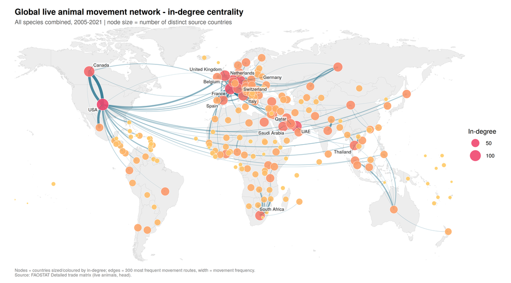

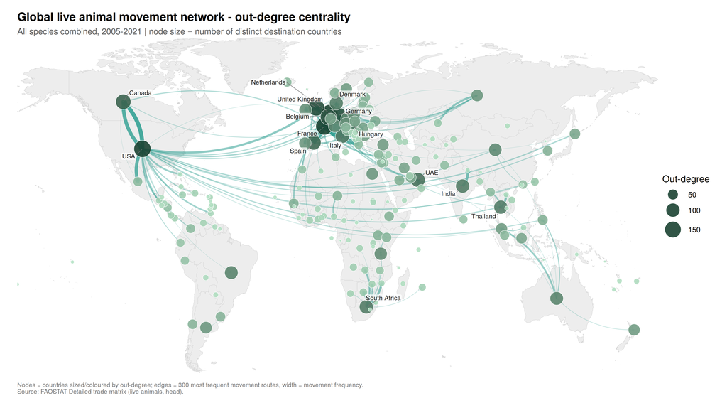

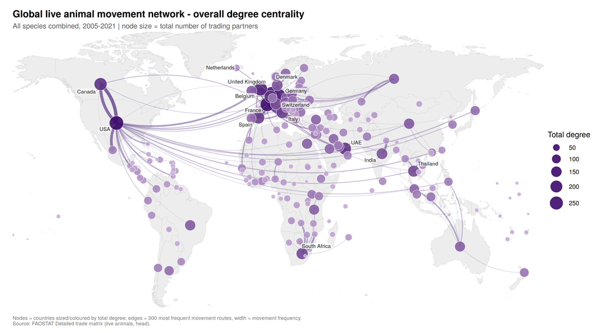

```r
period <- paste0(min(movements$year), "-", max(movements$year))

p_in <- plot_network_map(
  edges_all, cent_all, "in_degree",
  title    = "Global live animal movement network - in-degree centrality",
  subtitle = paste0("All species combined, ", period,
                    " | node size = number of distinct source countries"))

p_out <- plot_network_map(
  edges_all, cent_all, "out_degree",
  title    = "Global live animal movement network - out-degree centrality",
  subtitle = paste0("All species combined, ", period,
                    " | node size = number of distinct destination countries"),
  edge_colour = "#2a9d8f", node_palette = c("#b7e4c7", "#1b4332"))

p_tot <- plot_network_map(
  edges_all, cent_all, "total_degree",
  title    = "Global live animal movement network - overall degree centrality",
  subtitle = paste0("All species combined, ", period,
                    " | node size = total number of trading partners"),
  edge_colour = "#6a4c93", node_palette = c("#cdb4db", "#3c096c"))

p_in; p_out; p_tot
```

```r
save_map(p_in,  file.path(fig_dir, "network_map_in_degree_all_species.png"))
save_map(p_out, file.path(fig_dir, "network_map_out_degree_all_species.png"))
save_map(p_tot, file.path(fig_dir, "network_map_total_degree_all_species.png"))
```

# 7 Species-specific networks

The same three networks are rebuilt for every species in the data. Because species sub-networks are sparser, fewer edges are drawn.

```r
species <- movements %>%
  dplyr::count(item, sort = TRUE) %>%
  dplyr::pull(item)

slug <- function(x) x %>% stringr::str_to_lower() %>%
  stringr::str_replace_all("[^a-z0-9]+", "_") %>% stringr::str_replace_all("^_|_$", "")

measures <- c(in_degree = "#1f6f8b", out_degree = "#2a9d8f", total_degree = "#6a4c93")
palettes <- list(in_degree    = c("#ffd166", "#ef476f"),
                 out_degree   = c("#b7e4c7", "#1b4332"),
                 total_degree = c("#cdb4db", "#3c096c"))

species_edges <- list(); species_cent <- list(); species_stats <- list()

for (sp in species) {
  d_sp <- movements %>% dplyr::filter(item == sp)
  e_sp <- build_edges(d_sp)
  g_sp <- build_graph(e_sp)
  c_sp <- centrality_table(g_sp)

  species_edges[[sp]] <- e_sp %>% dplyr::mutate(species = sp, .before = 1)
  species_cent[[sp]]  <- c_sp %>% dplyr::mutate(species = sp, .before = 1)
  species_stats[[sp]] <- net_stats(g_sp, sp)

  for (m in names(measures)) {
    ttl <- paste0(sp, " movement network - ",
                  switch(m, in_degree = "in-degree", out_degree = "out-degree",
                         total_degree = "overall degree"), " centrality")
    p <- plot_network_map(e_sp, c_sp, m,
                          title = ttl,
                          subtitle = paste0(sp, ", ", period, " | ",
                                            igraph::vcount(g_sp), " countries, ",
                                            igraph::ecount(g_sp), " routes"),
                          top_edges = 150, n_labels = 12,
                          edge_colour = unname(measures[m]),
                          node_palette = palettes[[m]])
    save_map(p, file.path(spp_dir, paste0("network_map_", m, "_", slug(sp), ".png")))
  }
}

species_edges <- dplyr::bind_rows(species_edges)
species_cent  <- dplyr::bind_rows(species_cent)
species_stats <- dplyr::bind_rows(species_stats)
```

```r
species_stats
```

```
## # A tibble: 15 x 12
##    network       n_nodes n_edges density reciprocity transitivity mean_in_degree
##    <chr>           <int>   <dbl>   <dbl>       <dbl>        <dbl>          <dbl>
##  1 Horses            194    4089  0.109        0.616       0.468           21.1
##  2 Chickens          197    2679  0.0694       0.330       0.351           13.6
##  3 Cattle            196    2607  0.0682       0.427       0.418           13.3
##  4 Swine / pigs      186    1445  0.0420       0.396       0.382            7.77
##  5 Sheep             186    1477  0.0429       0.363       0.350            7.94
##  6 Turkeys           179     914  0.0287       0.313       0.254            5.11
##  7 Goats             186    1159  0.0337       0.305       0.278            6.23
##  8 Rabbits and ~     161    1162  0.0451       0.386       0.337            7.22
##  9 Ducks             182     990  0.0301       0.236       0.259            5.44
## 10 Mules and hi~     163    1025  0.0388       0.414       0.309            6.29
## 11 Asses             148     606  0.0279       0.393       0.275            4.09
## 12 Camels            130     522  0.0311       0.307       0.239            4.02
## 13 Geese             136     329  0.0179       0.207       0.191            2.42
## 14 Buffalo           131     442  0.0260       0.244       0.215            3.37
## 15 Other rodents     103     200  0.0190       0.38        0.0181           1.94
## # i 5 more variables: mean_out_degree <dbl>, max_in_degree <dbl>,
## #   max_out_degree <dbl>, diameter <dbl>, n_components_weak <int>
```

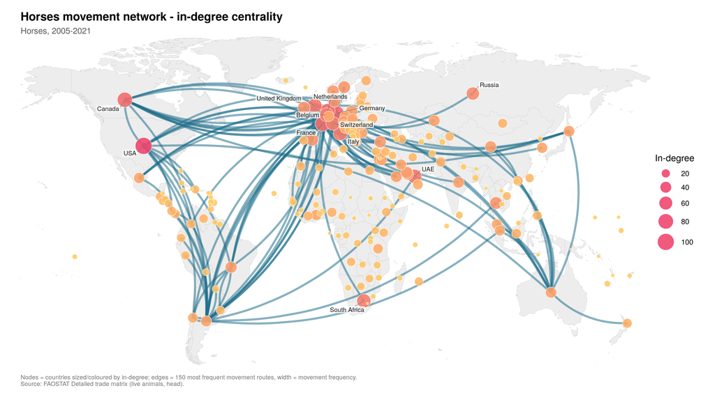

```r
# preview: the three networks for the most frequently traded species
sp1  <- species[1]
d_sp1 <- movements %>% dplyr::filter(item == sp1)
e_sp1 <- build_edges(d_sp1); g_sp1 <- build_graph(e_sp1); c_sp1 <- centrality_table(g_sp1)
plot_network_map(e_sp1, c_sp1, "in_degree",
                 title = paste0(sp1, " movement network - in-degree centrality"),
                 subtitle = paste0(sp1, ", ", period), top_edges = 150, n_labels = 12)
```

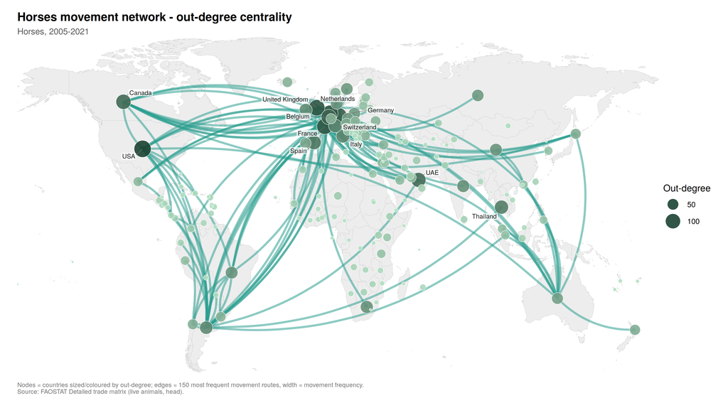

```r
plot_network_map(e_sp1, c_sp1, "out_degree",
                 title = paste0(sp1, " movement network - out-degree centrality"),
                 subtitle = paste0(sp1, ", ", period), top_edges = 150, n_labels = 12,
                 edge_colour = "#2a9d8f", node_palette = c("#b7e4c7", "#1b4332"))
```

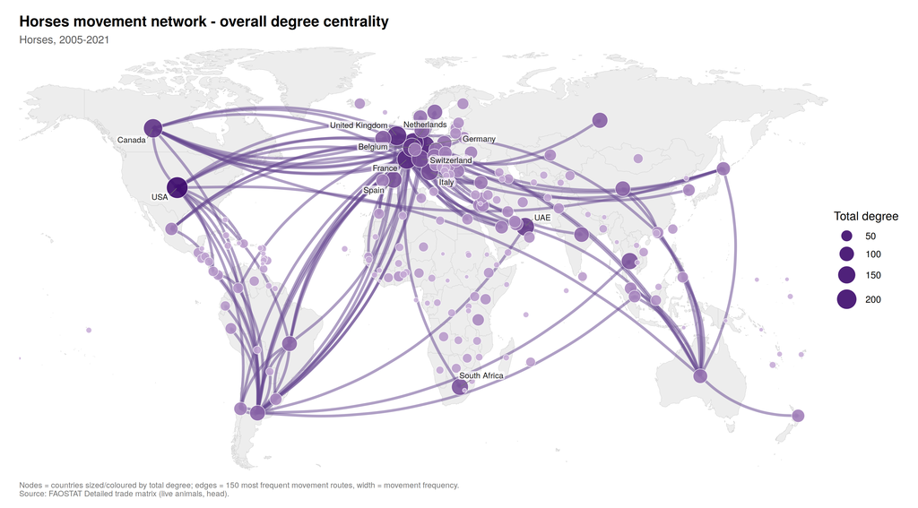

```r
plot_network_map(e_sp1, c_sp1, "total_degree",
                 title = paste0(sp1, " movement network - overall degree centrality"),
                 subtitle = paste0(sp1, ", ", period), top_edges = 150, n_labels = 12,
                 edge_colour = "#6a4c93", node_palette = c("#cdb4db", "#3c096c"))
```

# 8 Exported objects

```r
readr::write_csv(edges_all,     file.path(net_dir, "edges_all_species.csv"))
readr::write_csv(cent_all,      file.path(net_dir, "centrality_all_species.csv"))
readr::write_csv(species_edges, file.path(net_dir, "edges_by_species.csv"))
readr::write_csv(species_cent,  file.path(net_dir, "centrality_by_species.csv"))
readr::write_csv(movements,     file.path(net_dir, "movements_clean.csv"))
saveRDS(list(graph_all = g_all, edges_all = edges_all, centrality_all = cent_all,
             movements = movements, coords = coords),
        file.path(net_dir, "sna_objects.rds"))
```

```r
notes <- tibble::tribble(
  ~Item, ~Detail,
  "Source", "FAOSTAT Detailed trade matrix (domain TM), live animals, CSV extracts in Data/",
  "Files", paste(length(files), "CSV files"),
  "Important", "File names do NOT match the year of their contents; year is taken from the Year column",
  "Years covered", paste(sort(unique(movements$year)), collapse = ", "),
  "Years missing", if (length(missing_years)) paste(missing_years, collapse = ", ") else "none",
  "Raw rows", format(nrow(fao_raw), big.mark = ","),
  "Exact duplicate rows", "0",
  "Duplicates on natural key", "0",
  "Unit handling", "Only head-count units kept (An, 1000 An -> head); tonnes rows excluded to avoid double counting",
  "Direction rule", "Export Quantity: reporter -> partner; Import Quantity: partner -> reporter",
  "Mirror handling", "One movement = origin x destination x species x year; max reported head kept",
  "Unique movements", format(nrow(movements), big.mark = ","),
  "Edge weight", "Frequency of movement = number of distinct species-year movements on the route",
  "Node weight", "In-degree / out-degree / total degree centrality (unweighted and weighted strength both reported)",
  "Entities", paste0(nrow(country_dict), " M49 entities, 1:1 code-to-name. Territories (China mainland/Hong Kong/Macao/Taiwan) and historical entities (Sudan (former), Serbia and Montenegro) are kept as separate nodes"),
  "Coordinates", "Country centroids from Natural Earth matched on M49 code; France, Norway, Sudan (former) and Serbia and Montenegro set manually",
  "Generated", format(Sys.time(), "%Y-%m-%d %H:%M")
)

wb_sheets <- list(
  "Notes"                = notes,
  "File_Inventory"       = file_year_map,
  "Column_Check"         = col_check,
  "Class_Check"          = class_check,
  "Missing_Values"       = missing_tbl,
  "Duplicate_Check"      = dup_tbl,
  "Variable_Overview"    = variable_overview,
  "Categorical_Freq"     = categorical_freq,
  "Value_by_Element_Unit"= value_by_element_unit,
  "Value_by_Year"        = value_by_year,
  "Head_by_Species"      = head_by_species,
  "Head_by_Year"         = head_by_year,
  "Year_Summary"         = year_summary,
  "Country_Summary"      = country_summary,
  "Movement_Reporting"   = janitor_tbl,
  "Network_Summary_All"  = stats_all,
  "Network_Summary_Spp"  = species_stats,
  "Centrality_All"       = cent_all,
  "Centrality_by_Species"= species_cent,
  "Top_Edges_All"        = utils::head(edges_all, 500)
)

wb_sheets <- lapply(wb_sheets, function(df) {
  df %>%
    tibble::as_tibble() %>%
    dplyr::mutate(dplyr::across(dplyr::where(is.numeric), ~ round(.x, 4)))
})
```

## 8.1 One chart per sheet

Every sheet of the workbook gets its own figure, drawn from exactly the data on that sheet and embedded to the right of the table. The figures are also saved individually to `Output/figures/charts/`.

```r
chart_dir <- file.path(fig_dir, "charts")
dir.create(chart_dir, showWarnings = FALSE, recursive = TRUE)

pal  <- c(main = "#1f6f8b", alt = "#e07a5f", ok = "#2a9d8f", warn = "#e63946",
          grey = "grey60")

theme_desc <- function(base = 11) {
  ggplot2::theme_minimal(base_size = base) +
    ggplot2::theme(
      plot.title    = ggplot2::element_text(face = "bold", size = base + 2),
      plot.subtitle = ggplot2::element_text(colour = "grey35", size = base - 1),
      plot.caption  = ggplot2::element_text(colour = "grey50", size = base - 3, hjust = 0),
      panel.grid.minor = ggplot2::element_blank(),
      strip.text    = ggplot2::element_text(face = "bold", size = base - 2),
      legend.position = "bottom",
      plot.background = ggplot2::element_rect(fill = "white", colour = NA)
    )
}

# short country labels for the charts (falls back to the FAO name)
lab_of <- function(x) {
  out <- coords$label[match(x, coords$country)]
  dplyr::coalesce(out, x)
}

sheet_plots <- list()

## 1. Notes - the cleaning pipeline that the notes describe
sheet_plots$Notes <- {
  pipe <- tibble::tibble(
    stage = c("Raw rows read", "Head-count rows\n(An / 1000 An)", "Unique movements\n(mirror collapsed)",
              "Directed edges\n(country pairs)", "Country nodes"),
    n     = c(nrow(fao_raw), nrow(mov), nrow(movements), nrow(edges_all), igraph::vcount(g_all))
  ) %>% dplyr::mutate(stage = factor(stage, levels = rev(stage)))
  ggplot2::ggplot(pipe, ggplot2::aes(n, stage)) +
    ggplot2::geom_col(fill = pal["main"], width = .68) +
    ggplot2::geom_text(ggplot2::aes(label = scales::comma(n)), hjust = -0.12, size = 3.4) +
    ggplot2::scale_x_continuous(labels = scales::comma,
                                expand = ggplot2::expansion(mult = c(0, .18))) +
    ggplot2::labs(title = "From raw records to network elements",
                  subtitle = "Effect of the cleaning rules described on this sheet",
                  x = "Records", y = NULL) +
    theme_desc()
}

## 2. File_Inventory - rows per file, ordered by the year they actually contain
sheet_plots$File_Inventory <- {
  d <- file_year_map %>%
    dplyr::mutate(yr = as.integer(years_in_file)) %>%
    dplyr::arrange(yr) %>%
    dplyr::mutate(lbl = paste0(source_file, "  (", years_in_file, ")"),
                  lbl = factor(lbl, levels = rev(lbl)))
  ggplot2::ggplot(d, ggplot2::aes(n_rows, lbl, fill = yr)) +
    ggplot2::geom_col(width = .72) +
    ggplot2::geom_text(ggplot2::aes(label = scales::comma(n_rows)), hjust = -0.12, size = 3) +
    ggplot2::scale_fill_gradient(low = "#a8dadc", high = "#1d3557", name = "Year in file") +
    ggplot2::scale_x_continuous(labels = scales::comma,
                                expand = ggplot2::expansion(mult = c(0, .18))) +
    ggplot2::labs(title = "Records per source file",
                  subtitle = "File names do not match their contents - the year in brackets is the year of the data",
                  x = "Rows", y = NULL) +
    theme_desc()
}

## 3. Column_Check - every file must carry the same 17 variables
sheet_plots$Column_Check <- {
  d <- col_check %>%
    dplyr::mutate(status = ifelse(identical_names, "Identical to reference", "Different"),
                  source_file = factor(source_file, levels = rev(sort(source_file))))
  ggplot2::ggplot(d, ggplot2::aes(n_columns, source_file, fill = status)) +
    ggplot2::geom_col(width = .72) +
    ggplot2::geom_text(ggplot2::aes(label = n_columns), hjust = -0.3, size = 3) +
    ggplot2::scale_fill_manual(values = c("Identical to reference" = unname(pal["ok"]),
                                          "Different" = unname(pal["warn"])), name = NULL) +
    ggplot2::scale_x_continuous(expand = ggplot2::expansion(mult = c(0, .15))) +
    ggplot2::labs(title = "Variable structure of every file",
                  subtitle = paste0("All ", nrow(d), " files share the same ",
                                    unique(d$n_columns)[1], " column names, in the same order"),
                  x = "Number of columns", y = NULL) +
    theme_desc()
}

## 4. Class_Check - the class each variable resolves to
sheet_plots$Class_Check <- {
  d <- dplyr::bind_rows(
    class_check %>%
      dplyr::count(class = distinct_classes, name = "n_variables") %>%
      dplyr::mutate(stage = "As read from the CSVs"),
    variable_overview %>%
      dplyr::count(class = type, name = "n_variables") %>%
      dplyr::mutate(stage = "After the single coercion step")
  ) %>%
    dplyr::mutate(stage = factor(stage, levels = c("As read from the CSVs",
                                                   "After the single coercion step")))
  ggplot2::ggplot(d, ggplot2::aes(stats::reorder(class, n_variables), n_variables,
                                  fill = stage)) +
    ggplot2::geom_col(width = .62) +
    ggplot2::geom_text(ggplot2::aes(label = n_variables), vjust = -0.45, size = 3.4) +
    ggplot2::facet_wrap(~ stage, scales = "free_x") +
    ggplot2::scale_y_continuous(expand = ggplot2::expansion(mult = c(0, .18))) +
    ggplot2::scale_fill_manual(values = c(unname(pal["grey"]), unname(pal["main"])),
                               guide = "none") +
    ggplot2::labs(title = "Column classes agree across all files",
                  subtitle = "Every file is read as text, then coerced once - so no file can type a column differently",
                  x = NULL, y = "Number of variables") +
    theme_desc()
}

## 5. Missing_Values
sheet_plots$Missing_Values <- {
  d <- missing_tbl %>% dplyr::mutate(variable = factor(variable, levels = rev(variable)))
  ggplot2::ggplot(d, ggplot2::aes(pct_missing, variable)) +
    ggplot2::geom_col(fill = ifelse(d$pct_missing > 0, pal["warn"], pal["ok"]), width = .7) +
    ggplot2::geom_text(ggplot2::aes(label = paste0(n_missing, " missing")),
                       hjust = -0.1, size = 3, colour = "grey30") +
    ggplot2::scale_x_continuous(limits = c(0, max(1, max(d$pct_missing) * 1.4)),
                                labels = function(x) paste0(x, "%")) +
    ggplot2::labs(title = "Missing values by variable",
                  subtitle = paste0("Complete dataset: ", sum(missing_tbl$n_missing),
                                    " missing cells across ", scales::comma(nrow(fao)), " rows"),
                  x = "% missing", y = NULL) +
    theme_desc()
}
```

```r
## 6. Duplicate_Check
sheet_plots$Duplicate_Check <- {
  d <- dup_tbl %>%
    dplyr::mutate(
      status = ifelse(n_duplicates == 0, "No duplication",
                      "Expected: same shipment restated in another unit"),
      check  = stringr::str_wrap(check, 38),
      check  = factor(check, levels = rev(check)))
  ggplot2::ggplot(d, ggplot2::aes(n_duplicates, check, fill = status)) +
    ggplot2::geom_col(width = .6) +
    ggplot2::geom_text(ggplot2::aes(label = scales::comma(n_duplicates)),
                       hjust = -0.2, size = 3.6) +
    ggplot2::scale_fill_manual(values = c("No duplication" = unname(pal["ok"]),
      "Expected: same shipment restated in another unit" = unname(pal["alt"])),
      name = NULL) +
    ggplot2::scale_x_continuous(labels = scales::comma,
                                limits = c(0, max(1, max(d$n_duplicates) * 1.35))) +
    ggplot2::labs(title = "Duplicate checks",
                  subtitle = stringr::str_wrap(paste(
                    "No genuine duplicate exists. The third count is the same shipment restated",
                    "in another unit (An / 1000 An / t), which the head-count filter removes."), 80),
                  x = "Duplicated rows found", y = NULL) +
    theme_desc()
}

## 7. Variable_Overview - distinct values per variable
sheet_plots$Variable_Overview <- {
  d <- variable_overview %>%
    dplyr::arrange(n_unique) %>%
    dplyr::mutate(variable = factor(variable, levels = variable))
  ggplot2::ggplot(d, ggplot2::aes(n_unique, variable, fill = role)) +
    ggplot2::geom_col(width = .72) +
    ggplot2::geom_text(ggplot2::aes(label = scales::comma(n_unique)),
                       hjust = -0.15, size = 3) +
    ggplot2::scale_x_log10(labels = scales::comma,
                           expand = ggplot2::expansion(mult = c(0, .25))) +
    ggplot2::scale_fill_brewer(palette = "Set2", name = NULL) +
    ggplot2::labs(title = "Distinct values per variable",
                  subtitle = "Log scale - shows which columns are constants, keys or measures",
                  x = "Distinct values (log scale)", y = NULL) +
    theme_desc()
}

## 8. Categorical_Freq
sheet_plots$Categorical_Freq <- {
  d <- categorical_freq %>%
    dplyr::group_by(variable) %>%
    dplyr::slice_max(n, n = 8, with_ties = FALSE) %>%
    dplyr::ungroup() %>%
    dplyr::mutate(short = stringr::str_trunc(level, 26),
                  key   = paste(variable, level, sep = " | "),
                  key   = stats::reorder(key, n))
  key_labels <- stats::setNames(d$short, as.character(d$key))
  ggplot2::ggplot(d, ggplot2::aes(n, key)) +
    ggplot2::geom_col(fill = pal["main"], width = .7) +
    ggplot2::scale_y_discrete(labels = key_labels) +
    ggplot2::scale_x_continuous(labels = scales::label_number(scale_cut =
                                  scales::cut_short_scale()),
                                expand = ggplot2::expansion(mult = c(0, .08)),
                                n.breaks = 4) +
    ggplot2::facet_wrap(~ variable, scales = "free", ncol = 3) +
    ggplot2::labs(title = "Frequency of each level of the categorical variables",
                  subtitle = "Up to eight most frequent levels per variable",
                  x = "Records", y = NULL) +
    theme_desc(10) +
    ggplot2::theme(plot.margin = ggplot2::margin(10, 18, 10, 10))
}

## 9. Value_by_Element_Unit
sheet_plots$Value_by_Element_Unit <- {
  d <- value_by_element_unit %>%
    dplyr::mutate(grp = paste(element, "-", unit))
  ggplot2::ggplot(d, ggplot2::aes(stats::reorder(grp, n), n, fill = element)) +
    ggplot2::geom_col(width = .7) +
    ggplot2::geom_text(ggplot2::aes(label = paste0(scales::comma(n), "\nmedian ",
                                                   scales::comma(round(median)))),
                       hjust = -0.08, size = 3, lineheight = .95) +
    ggplot2::coord_flip() +
    ggplot2::scale_y_continuous(labels = scales::comma,
                                expand = ggplot2::expansion(mult = c(0, .28))) +
    ggplot2::scale_fill_manual(values = c("Import Quantity" = unname(pal["main"]),
                                          "Export Quantity" = unname(pal["alt"])),
                               name = NULL) +
    ggplot2::labs(title = "Records and typical size by element and unit",
                  subtitle = "Head (An), thousand head (1000 An) and tonnes (t) restate the same shipments",
                  x = NULL, y = "Records") +
    theme_desc()
}

## 10. Value_by_Year - distribution of the reported value through time
sheet_plots$Value_by_Year <- {
  d <- value_by_year %>%
    dplyr::select(year, q1, median, q3, mean) %>%
    tidyr::pivot_longer(c(median, mean), names_to = "stat", values_to = "value") %>%
    dplyr::mutate(stat = dplyr::recode(stat,
      median = "Median (with inter-quartile band)", mean = "Mean"))
  ggplot2::ggplot(d, ggplot2::aes(year, value)) +
    ggplot2::geom_ribbon(data = dplyr::filter(d, stat != "Mean"),
                         ggplot2::aes(ymin = q1, ymax = q3),
                         fill = pal["main"], alpha = .20) +
    ggplot2::geom_line(ggplot2::aes(colour = stat), linewidth = .9) +
    ggplot2::geom_point(ggplot2::aes(colour = stat), size = 1.9) +
    ggplot2::facet_wrap(~ stat, scales = "free_y", ncol = 1) +
    ggplot2::scale_x_continuous(breaks = value_by_year$year) +
    ggplot2::scale_y_continuous(labels = scales::comma) +
    ggplot2::scale_colour_manual(values = stats::setNames(
      c(unname(pal["alt"]), unname(pal["main"])),
      c("Mean", "Median (with inter-quartile band)")), guide = "none") +
    ggplot2::labs(title = "Reported quantity per record, by year",
                  subtitle = "All units pooled - the mean is pulled up by a few very large poultry consignments",
                  x = NULL, y = "Value per record") +
    theme_desc()
}

## 11. Head_by_Species
sheet_plots$Head_by_Species <- {
  d <- head_by_species %>%
    dplyr::mutate(item = stats::reorder(item, sum))
  ggplot2::ggplot(d, ggplot2::aes(sum, item)) +
    ggplot2::geom_col(fill = pal["main"], width = .72) +
    ggplot2::geom_text(ggplot2::aes(label = paste0(scales::label_number(scale_cut =
                         scales::cut_short_scale())(sum), "  (", scales::comma(n), " mov.)")),
                       hjust = -0.06, size = 3) +
    ggplot2::scale_x_continuous(labels = scales::label_number(scale_cut =
                                  scales::cut_short_scale()),
                                expand = ggplot2::expansion(mult = c(0, .3))) +
    ggplot2::labs(title = "Animals moved by species, 2005-2021",
                  subtitle = "Total head over all movements; movement count in brackets",
                  x = "Head", y = NULL) +
    theme_desc()
}
```

```r
## 12. Head_by_Year
sheet_plots$Head_by_Year <- {
  ggplot2::ggplot(head_by_year, ggplot2::aes(year, sum)) +
    ggplot2::geom_col(fill = pal["main"], width = .68) +
    ggplot2::geom_vline(xintercept = 2019, linetype = "22", colour = pal["warn"]) +
    ggplot2::annotate("text", x = 2019, y = max(head_by_year$sum) * .96,
                      label = "2019 not in the data", colour = pal["warn"],
                      angle = 90, vjust = -0.5, size = 3) +
    ggplot2::scale_x_continuous(breaks = head_by_year$year) +
    ggplot2::scale_y_continuous(labels = scales::label_number(scale_cut =
                                  scales::cut_short_scale())) +
    ggplot2::labs(title = "Total animals moved per year",
                  subtitle = "Sum of head over all species and all routes",
                  x = NULL, y = "Head") +
    theme_desc()
}

## 13. Year_Summary
sheet_plots$Year_Summary <- {
  d <- year_summary %>%
    dplyr::select(year, n_movements, n_origins, n_destinations, n_species) %>%
    tidyr::pivot_longer(-year, names_to = "metric", values_to = "value") %>%
    dplyr::mutate(metric = dplyr::recode(metric,
      n_movements = "Movements recorded", n_origins = "Exporting countries",
      n_destinations = "Importing countries", n_species = "Species traded"))
  ggplot2::ggplot(d, ggplot2::aes(year, value, colour = metric)) +
    ggplot2::geom_vline(xintercept = 2019, linetype = "22", colour = "grey65") +
    ggplot2::geom_line(linewidth = .9) + ggplot2::geom_point(size = 1.8) +
    ggplot2::facet_wrap(~ metric, scales = "free_y", ncol = 2) +
    ggplot2::scale_x_continuous(breaks = seq(2005, 2021, 4)) +
    ggplot2::scale_y_continuous(labels = scales::comma) +
    ggplot2::scale_colour_brewer(palette = "Dark2", guide = "none") +
    ggplot2::labs(title = "Coverage of the network through time",
                  subtitle = "Dashed line marks 2019, which is absent from the source files - the series joins 2018 to 2020",
                  x = NULL, y = NULL) +
    theme_desc()
}

## 14. Country_Summary
sheet_plots$Country_Summary <- {
  d <- country_summary %>%
    dplyr::mutate(total = out_movements + in_movements) %>%
    dplyr::slice_max(total, n = 20) %>%
    dplyr::mutate(country = lab_of(country),
                  country = stats::reorder(country, total)) %>%
    dplyr::select(country, `Movements out` = out_movements,
                  `Movements in` = in_movements) %>%
    tidyr::pivot_longer(-country, names_to = "direction", values_to = "n")
  ggplot2::ggplot(d, ggplot2::aes(n, country, fill = direction)) +
    ggplot2::geom_col(width = .74) +
    ggplot2::scale_fill_manual(values = c("Movements out" = unname(pal["alt"]),
                                          "Movements in"  = unname(pal["main"])), name = NULL) +
    ggplot2::scale_x_continuous(labels = scales::comma) +
    ggplot2::labs(title = "Twenty busiest countries",
                  subtitle = "Movements recorded as origin and as destination, 2005-2021",
                  x = "Movements", y = NULL) +
    theme_desc()
}

## 15. Movement_Reporting
sheet_plots$Movement_Reporting <- {
  d <- janitor_tbl %>%
    dplyr::mutate(pct = n_movements / sum(n_movements),
                  reported_by = stats::reorder(reported_by, n_movements))
  ggplot2::ggplot(d, ggplot2::aes(n_movements, reported_by, fill = reported_by)) +
    ggplot2::geom_col(width = .62) +
    ggplot2::geom_text(ggplot2::aes(label = paste0(scales::comma(n_movements), "  (",
                                                   scales::percent(pct, accuracy = .1), ")")),
                       hjust = -0.06, size = 3.4) +
    ggplot2::scale_x_continuous(labels = scales::comma,
                                expand = ggplot2::expansion(mult = c(0, .3))) +
    ggplot2::scale_fill_manual(values = c("both sides" = unname(pal["ok"]),
                                          "exporter only" = unname(pal["alt"]),
                                          "importer only" = unname(pal["main"])),
                               guide = "none") +
    ggplot2::labs(title = "Who reported each movement",
                  subtitle = "Nearly half of all movements were reported by both trading partners and had to be collapsed",
                  x = "Movements", y = NULL) +
    theme_desc()
}

## 16. Network_Summary_All
sheet_plots$Network_Summary_All <- {
  d <- stats_all %>%
    dplyr::select(-network) %>%
    tidyr::pivot_longer(dplyr::everything(), names_to = "metric", values_to = "value") %>%
    dplyr::mutate(
      panel = ifelse(metric %in% c("density", "reciprocity", "transitivity"),
                     "Proportions (0-1)", "Counts"),
      metric = dplyr::recode(metric,
        n_nodes = "Countries", n_edges = "Routes", density = "Density",
        reciprocity = "Reciprocity", transitivity = "Transitivity",
        mean_in_degree = "Mean in-degree", mean_out_degree = "Mean out-degree",
        max_in_degree = "Max in-degree", max_out_degree = "Max out-degree",
        diameter = "Diameter", n_components_weak = "Weak components"))
  ggplot2::ggplot(d, ggplot2::aes(value, stats::reorder(metric, value), colour = panel)) +
    ggplot2::geom_segment(ggplot2::aes(x = 0.1, xend = value, yend = metric),
                          linewidth = .9) +
    ggplot2::geom_point(size = 3.6) +
    ggplot2::geom_text(ggplot2::aes(label = ifelse(value < 1, round(value, 3),
                                                   scales::comma(round(value, 1)))),
                       hjust = -0.35, size = 3.2, colour = "grey20") +
    ggplot2::scale_x_log10(labels = scales::comma,
                           expand = ggplot2::expansion(mult = c(0.02, .22))) +
    ggplot2::scale_colour_manual(values = c("Counts" = unname(pal["main"]),
                                            "Proportions (0-1)" = unname(pal["alt"])),
                                 name = NULL) +
    ggplot2::labs(title = "Structure of the combined network",
                  subtitle = "All species, all years - log scale, so proportions and counts fit on one axis",
                  x = "Value (log scale)", y = NULL) +
    theme_desc()
}
```

```r
## 17. Network_Summary_Spp
sheet_plots$Network_Summary_Spp <- {
  ggplot2::ggplot(species_stats,
                  ggplot2::aes(n_nodes, n_edges, size = density, colour = reciprocity)) +
    ggplot2::geom_point(alpha = .85) +
    ggrepel::geom_text_repel(ggplot2::aes(label = network), size = 3,
                             colour = "grey20", seed = 1, max.overlaps = 30) +
    ggplot2::scale_size_continuous(range = c(2, 10), name = "Density") +
    ggplot2::scale_colour_gradient(low = "#a8dadc", high = "#1d3557", name = "Reciprocity") +
    ggplot2::scale_y_continuous(labels = scales::comma) +
    ggplot2::labs(title = "Size and shape of each species network",
                  subtitle = "Countries involved vs routes used; point size = density",
                  x = "Countries in the network", y = "Directed routes") +
    theme_desc()
}

## 18. Centrality_All
sheet_plots$Centrality_All <- {
  d <- cent_all %>% dplyr::mutate(lbl = lab_of(country))
  top <- d %>% dplyr::slice_max(total_degree, n = 14, with_ties = FALSE)
  ggplot2::ggplot(d, ggplot2::aes(out_degree, in_degree)) +
    ggplot2::geom_abline(slope = 1, intercept = 0, linetype = "22", colour = "grey70") +
    ggplot2::geom_point(ggplot2::aes(colour = total_degree, size = total_degree), alpha = .85) +
    ggrepel::geom_text_repel(data = top, ggplot2::aes(label = lbl), size = 3,
                             colour = "grey15", seed = 1, max.overlaps = 30) +
    ggplot2::scale_colour_gradient(low = "#ffd166", high = "#7f1d3f", name = "Total degree") +
    ggplot2::scale_size_continuous(range = c(1.2, 7), guide = "none") +
    ggplot2::scale_x_continuous(expand = ggplot2::expansion(mult = .09)) +
    ggplot2::scale_y_continuous(expand = ggplot2::expansion(mult = .09)) +
    ggplot2::labs(title = "Exporting reach against importing reach",
                  subtitle = "Each point is a country; above the dashed line = imports from more partners than it exports to",
                  x = "Out-degree (countries supplied)", y = "In-degree (countries supplied by)") +
    theme_desc()
}

## 19. Centrality_by_Species
sheet_plots$Centrality_by_Species <- {
  top_c <- cent_all %>% dplyr::slice_max(total_degree, n = 20, with_ties = FALSE) %>%
    dplyr::pull(country)
  d <- species_cent %>%
    dplyr::filter(country %in% top_c) %>%
    dplyr::mutate(lbl = lab_of(country))
  ord <- d %>% dplyr::group_by(lbl) %>% dplyr::summarise(s = sum(total_degree)) %>%
    dplyr::arrange(s) %>% dplyr::pull(lbl)
  sp_ord <- d %>% dplyr::group_by(species) %>% dplyr::summarise(s = sum(total_degree)) %>%
    dplyr::arrange(dplyr::desc(s)) %>% dplyr::pull(species)
  d <- d %>% dplyr::mutate(lbl = factor(lbl, levels = ord),
                           species = factor(species, levels = sp_ord))
  ggplot2::ggplot(d, ggplot2::aes(species, lbl, fill = total_degree)) +
    ggplot2::geom_tile(colour = "white", linewidth = .4) +
    ggplot2::scale_fill_gradient(low = "#f1faee", high = "#1d3557", name = "Total degree") +
    ggplot2::labs(title = "Total degree of the twenty most connected countries, by species",
                  subtitle = "Darker = trades that species with more partners",
                  x = NULL, y = NULL) +
    theme_desc() +
    ggplot2::theme(axis.text.x = ggplot2::element_text(angle = 45, hjust = 1),
                   panel.grid = ggplot2::element_blank())
}

## 20. Top_Edges_All
sheet_plots$Top_Edges_All <- {
  d <- edges_all %>%
    dplyr::slice_max(weight, n = 20, with_ties = FALSE) %>%
    dplyr::mutate(route = paste(lab_of(from), "->", lab_of(to)),
                  route = stats::reorder(route, weight))
  ggplot2::ggplot(d, ggplot2::aes(weight, route, fill = n_species)) +
    ggplot2::geom_col(width = .74) +
    ggplot2::geom_text(ggplot2::aes(label = weight), hjust = -0.25, size = 3) +
    ggplot2::scale_fill_gradient(low = "#a8dadc", high = "#1d3557", name = "Species on route") +
    ggplot2::scale_x_continuous(expand = ggplot2::expansion(mult = c(0, .12))) +
    ggplot2::labs(title = "Twenty most frequently used routes",
                  subtitle = "Weight = number of distinct species-year movements on that route",
                  x = "Movement frequency", y = NULL) +
    theme_desc()
}

stopifnot(setequal(names(sheet_plots), names(wb_sheets)))

# chart size per sheet (inches)
chart_size <- list(
  Categorical_Freq      = c(11, 7.5),
  Year_Summary          = c(9, 6),
  Centrality_by_Species = c(9.5, 7),
  Network_Summary_All   = c(10, 5),
  File_Inventory        = c(9.5, 5.5),
  Variable_Overview     = c(9.5, 5.5),
  Country_Summary       = c(9, 6)
)
size_of <- function(nm) if (!is.null(chart_size[[nm]])) chart_size[[nm]] else c(9, 5)

chart_files <- vapply(names(sheet_plots), function(nm) {
  wh <- size_of(nm)
  f  <- file.path(chart_dir, paste0(nm, ".png"))
  ggplot2::ggsave(f, sheet_plots[[nm]], width = wh[1], height = wh[2], dpi = 150, bg = "white")
  f
}, character(1))
```

## 8.2 Writing the workbook

Each sheet holds its table on the left and its figure to the right of the data.

```r
xlsx_path <- file.path(tab_dir, "Descriptive_Statistics.xlsx")

wb  <- openxlsx::createWorkbook()
hdr <- openxlsx::createStyle(textDecoration = "bold", fgFill = "#1f6f8b",
                             fontColour = "white", halign = "left", border = "bottom")

for (nm in names(wb_sheets)) {
  df <- wb_sheets[[nm]]
  openxlsx::addWorksheet(wb, nm)
  openxlsx::writeData(wb, nm, df, headerStyle = hdr)
  openxlsx::freezePane(wb, nm, firstRow = TRUE)
  openxlsx::setColWidths(wb, nm, cols = seq_len(ncol(df)),
                         widths = pmin(60, pmax(10, nchar(names(df)) + 4)))
  wh <- size_of(nm)
  openxlsx::insertImage(wb, nm, chart_files[[nm]],
                        width = wh[1], height = wh[2],
                        startCol = ncol(df) + 2, startRow = 2)
}

openxlsx::saveWorkbook(wb, xlsx_path, overwrite = TRUE)

cat("Workbook written to", xlsx_path, "\n",
    length(wb_sheets), "sheets, each with its own chart:\n  ",
    paste(names(wb_sheets), collapse = ", "), "\n")
```

```
## Workbook written to Output/tables/Descriptive_Statistics.xlsx
##  20 sheets, each with its own chart:
##    Notes, File_Inventory, Column_Check, Class_Check, Missing_Values, Duplicate_Check, Variable_Overview, Categorical_Freq, Value_by_Element_Unit, Value_by_Year, Head_by_Species, Head_by_Year, Year_Summary, Country_Summary, Movement_Reporting, Network_Summary_All, Network_Summary_Spp, Centrality_A…
```